# Instalación de R Studio y Algunos Paquetes Necesarios

Equipo de tutores *Big Data e inteligencia territorial (FLACSO)

Mayo 2022

Para este curso necesitaremos tener instalado R y RStudio. Quienes tengan una versión anterior de R (4.2 es la última versión) es recomendable que realicen también estos pasos.

Para averiguar qué versión de R tienen instalado pueden mirar el primer mensaje en la consola al abrir Rstudio:

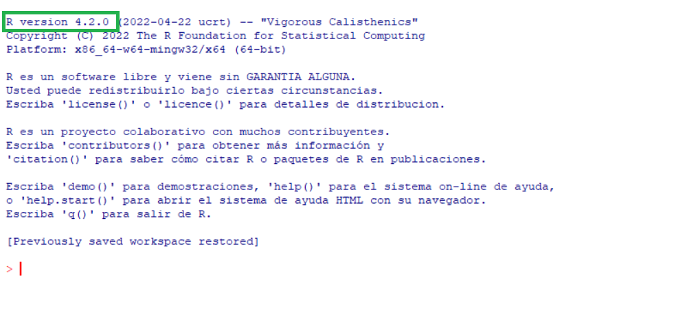

La instalación de estos programas se puede realizar en dos pasos.

# Paso 1: Instalación de R

## Para usuaries de Windows

Ir a https://cloud.r-project.org/ y hacer clic en *Download R for Windows*.

[figure not shown]

Se abrirá la siguiente página. Hacer clic en *install R for the first time*.

[figure not shown]

Se abrirá la siguiente página. Hacer clic en *Download R-4.2.0 for Windows*.

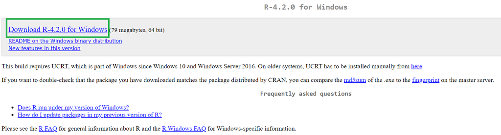

Se abrirá el siguiente cuadro de diálogo. Hacer clic en la ventana para habilitar el botón *Guardar archivo*.

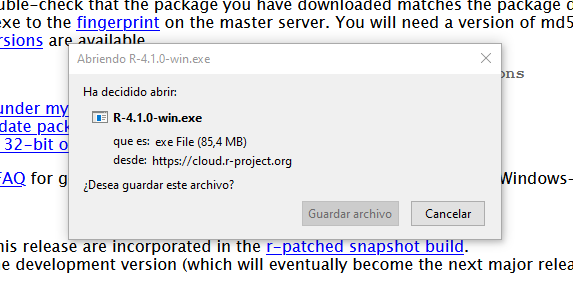

Ejecutar el archivo de instalación eligiendo las opciones por defecto.

[figure not shown]

### Instalación de Rtools

Les usuaries de Windows necesitarán además instalar **RTools**. Es importante destacar que se debe instalar la versión correspondiente a la instalación de R (para la versión de **R 4.2** y posteriores se debe utilizar **RTools42**).

Para instalar RTools deberá ir al siguiente [link](https://cran.r-project.org/bin/windows/Rtools/rtools42/rtools.html) y presionar en el link que dice *Rtools42 installer*.

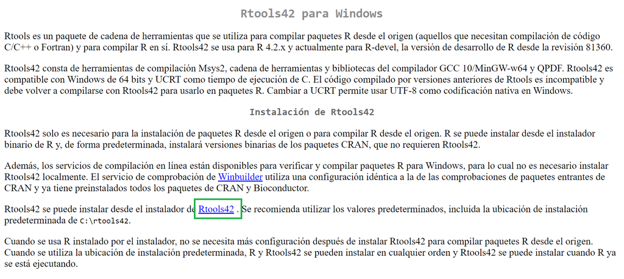

Esto descargará un archivo que deberán ejecutar. Es posible que el instalador requiera algunos permisos que deberán otorgar. Es muy recomendable que mantengan todas las configuraciones por defecto, en particular, el directorio de instalación (a saber: *C:\rtools42*), ya que de esta manera no se requerirá ninguna otra configuración y R + RTools estará listo para utilizar. Este programa es seguro y no instalará otra cosa que no sea RTools.

[figure not shown]

## Para los usuarios de Mac

Instalar R de https://cran.r-project.org/bin/macosx/ siguiendo los pasos.

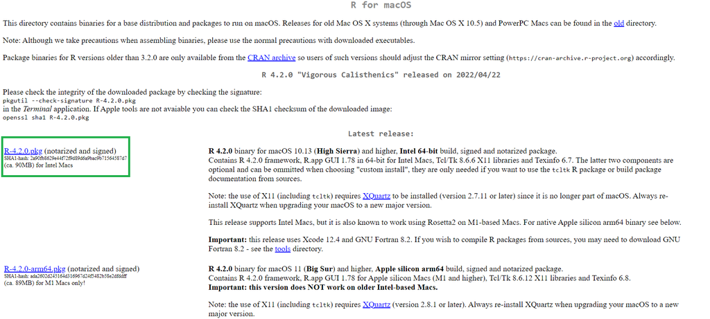

Para instalar R-Commander ([https://socialsciences.mcmaster.ca/jfox/Misc/Rcmdr/installation-notes.html)](https://socialsciences.mcmaster.ca/jfox/Misc/Rcmdr/installation-notes.html)) es necesario disponer de las librerías gráficas **X11**. Como a partir de **OS X Lion** ya no están instaladas por defecto en el sistema, es necesario instalar las librerías **Open Source XQuartz** desde https://www.xquartz.org.

Finalmente, abrir R. Una vez abierto, ejecutar en la consola de R para instalar **Rcmdr** el siguiente comando:

```r
install.packages("Rcmdr", dependencies = TRUE)
```

# Paso 2: Instalación de R Studio

Instalar RStudio de https://www.rstudio.com/products/rstudio/download/

Seleccionar del menú *Products Rstudio (the premier IDE form R)*, luego elegir la versión para escritorio y luego la versión gratutita:

[figure not shown]

Seleccionar el sistema operativo que usarán (Windows, MAC, Linux).

Guardar y luego ejecutar para instalar.

[figure not shown]

# Paso 3: Instalación de Paquetes

En este paso vamos a instalar algunos de los paquetes que utilizaremos en el curso **Big Data e inteligencia territorial (FLACSO)**.

Existen dos formas de instalar paquetes: la consola de R o mediante la interfaz de RStudio.

Para instalar los paquetes a través de la consola es necesario escribir (o copiar y pegar) la siguiente sentencia:

```r
install.packages("nombre_del_paquete")
```

*(recordar que el nombre del paquete siempre va entre comillas)*

Para instalar los paquetes a través de la interfaz de RStudio: Elegir la pestaña *Paquetes* o *Packages* (según el idioma), luego *Install* y se nos mostrará la ventana para instalar paquetes. Luego tenemos que verificar que la fuente de donde descargamos los paquetes sea el *«repositorio CRAN»*, a continuación escribimos el nombre del paquete.

Para este curso será necesario instalar los siquientes paquetes, a través de la siguiente sentencia en la consola:

```r
install.packages(c("tidyverse", "haven", "eph", "sf", "devtools", "ggmap", "lubridate",
                   "leaflet", "osmdata", "osrm", "ggmap", "rtweet"))
```